# RTI Data Science Exercise Step 4

### Step 4: Variable Associations With The Response

There were many interesting trends discovered in this step of the process. It revealed which variables needed to be transformed and the how to model each of the continuous variables.

The code behind the functions ‘plot_continuous’ and ‘plot_density’ used in this section can be found at the bottom of the page.

```r
library(tidyverse)
train <- read_csv('C:/Users/Will/Documents/MSA/jobs/rti_challenge/data-scientist-exercise01/data/train.csv')

train %>%
  mutate_each(funs(factor(.)), -c(age:hours_week)) %>%
  mutate(over_50k = as.numeric(as.character(over_50k)))-> train
```

**Age**  
The relationship between the log odds of making over 50k and Age is not linear. This is one of the most clearly defined relationships I have seen.

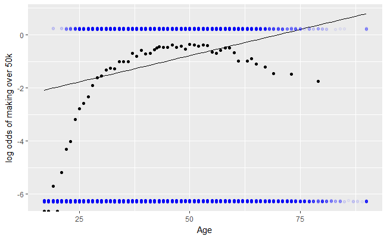

```r
plot_continuous(train$age, n = 300, response = train$over_50k, max_poly_degree = 1,
                log_odds = T, jitter_height = .025, variable_name = 'Age')
```

**Age**  
Here a third order polynomial of age is used to model whether a person is making over 50k or not. The max values of age may be mistakes in the data. I’d want to research these points on the job but for times sake I’ll leave them for now.

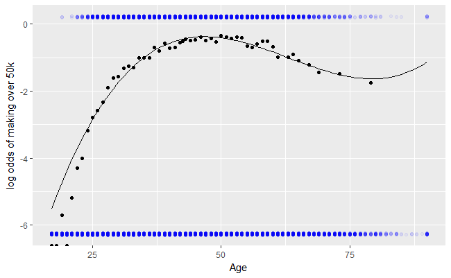

```r
plot_continuous(train$age, n = 300, response = train$over_50k, max_poly_degree = 3,
                log_odds = T, jitter_height = .025, variable_name = 'Age')
```

**education_num**  
The relationship between the log odds between making over 50k and education number appears to be linear, With the exception of the lower education levels.

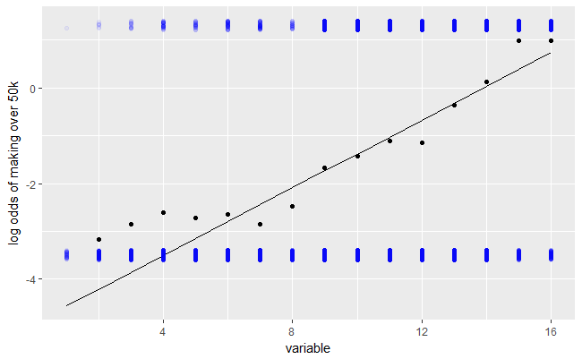

```r
plot_continuous(train$education_num, n = 100, response = train$over_50k, max_poly_degree = 1, log_odds = T)
```

**education_num**  
With the exception of the lower education levels, there is an approximately linear relationship. To adjust for the lower education numbers, all values below 8 are combined into a single category. Now the line has a much better fit.

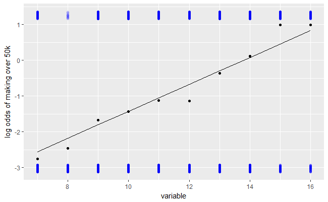

```r
train %>%
  mutate(education_num = ifelse(education_num < 8, 7, education_num)) -> train2

plot_continuous(train2$education_num, n = 100, response = train2$over_50k, max_poly_degree = 1, log_odds = T)
```

**capital_gain**  
This variable has an outlier at 99,999 that is causing some problems.

```
glm.fit: fitted probabilities numerically 0 or 1 occurred
```

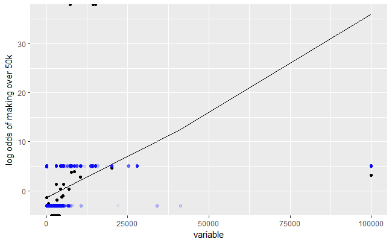

```r
plot_continuous(train$capital_gain , n = 100, response = train$over_50k, max_poly_degree = 1, log_odds = T)
```

**capital_gain**  
In this plot, capital gain is log scaled. The y-axis is in a probability form instead of log-odds. I added an indicator variable telling the model if the value is 0 or otherwise. It looks like there is great separation between over_50k using capital gain here. The line between x = 0 and x = 3 only looks like it is above y = 0 because there were no capital gain values between that range. If there were then the S shape would stay at y = 0, until x hit 0

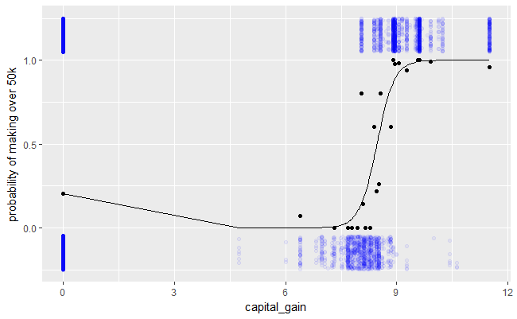

```r
train %>%
  mutate(capital_indicator = ifelse(capital_gain == 0, 1,0))-> train2

plot_continuous(log(train2$capital_gain + 1),int = train2$capital_indicator, n = 100, response = train2$over_50k,
                max_poly_degree = 1, log_odds = F, variable_name = 'capital_gain')
```

**capital_gain**  
We can see here that the capital gain distribution after 0 has near perfect separation between the response.

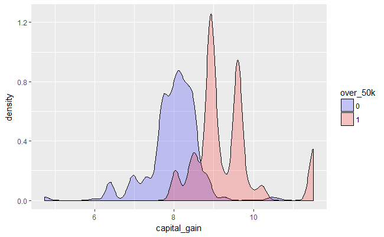

```r
train %>%
  filter(capital_gain > 0) -> train2

plot_density(log(train2$capital_gain + 1), response = train2$over_50k, variable_name = 'capital_gain')
```

**capital_loss**  
There appears to be a week relationship between capital_loss and the response

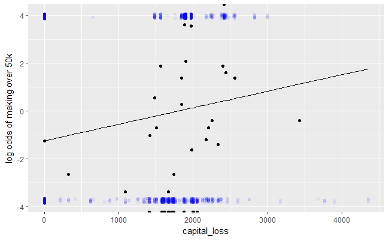

```r
plot_continuous(train$capital_loss, n = 30, response = train$over_50k,
                max_poly_degree = 1, log_odds = T, variable_name = 'capital_loss')
```

**capital_loss**  
It looks like the important distinction between this variable is that at 0, it is more likely to make less than 50k. Greater than 0 it is more likely to make more than 50k. Next I’ll filter out the zeros so I can better see the middle distribtion.

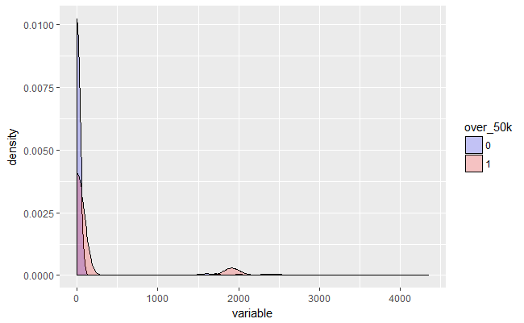

```r
plot_density(train$capital_loss, response = train$over_50k)
```

**capital_loss**  
After filtering out the zeros, There really is not much separation here. Instead I’ll convert this variable to be categorical. 0 if equal to 0, and 1 if greater than 0

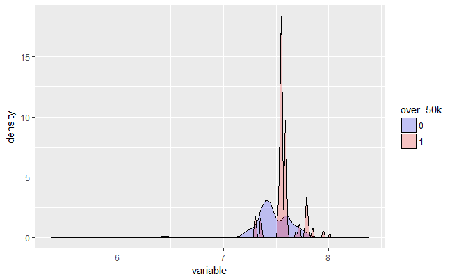

```r
train %>%
  filter(capital_loss > 0) -> train2

plot_density(log(train2$capital_loss + 1), response = train2$over_50k)
```

**hours_week**  
The log odds here are not linear at all. It looks like a 3rd order polynomial may fit the trend much better. The data also appears to have the same association with the response after 50 hours a week.

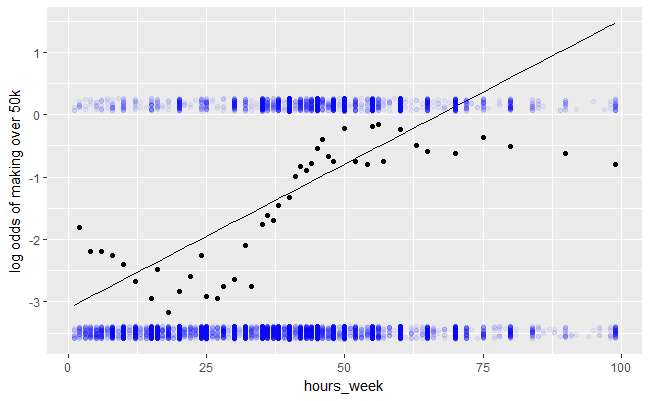

```r
plot_continuous(train$hours_week, n = 100, response = train$over_50k,
                max_poly_degree = 1, log_odds = T, variable_name = 'hours_week')
```

```r
##code used for plot in report:
# df <- plot_continuous(train$hours_week, n = 50, response = train$over_50k,
#                       max_poly_degree = 1, log_odds = T, variable_name = 'hours_week', out = T)
#
# ggplot(df$points, aes(x = point, y = prob_over50k)) + geom_point() + geom_smooth() +
# xlab('Hours Worked') + ylab('Probability of Making Over 50K') + ggtitle('Association Between Hours Worked and Making Over 50k') + theme(plot.title = element_text(hjust = 0.5))
```

**hours_week**  
The best way to fit the data I’ve found is to add an indicator variable if hours_week is over 50 or not, and add an interaction effect. I also considered condensing all the values past 50 to 50, but I don’t think that would have been a good long term solution.

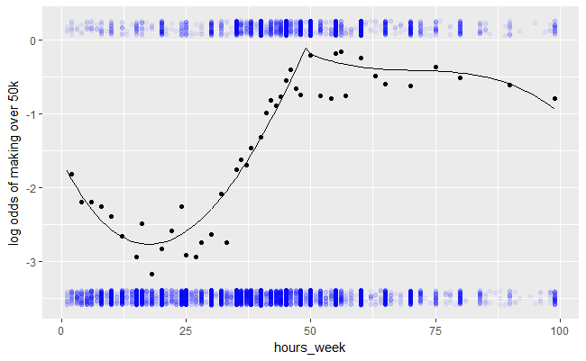

```r
train %>%
  mutate(hours_week1 = ifelse(hours_week >= 48, 50, hours_week),
         hours_indicator = ifelse(hours_week >= 50, 1,0)) ->  train2

plot_continuous(train2$hours_week, int = train2$hours_indicator,  n = 100,
                response = train2$over_50k, max_poly_degree = 3, log_odds = T, variable_name = 'hours_week')
```

**country**  
This plot shows the proportion of individuals making over 50k for each country. There is a significant difference in likelihood of earning over 50k between these countries. The difference in line color shows the sample size. The darker the color the larger the sample for that country.

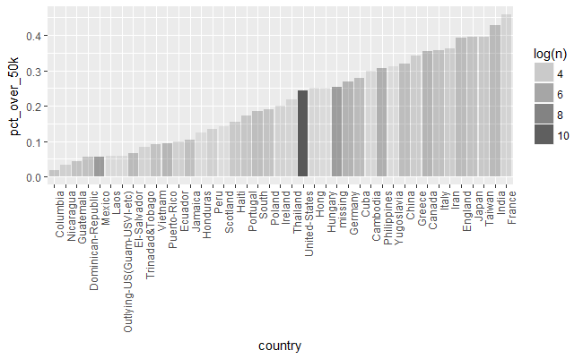

```r
train %>%
  group_by(country) %>%
  summarise(pct_over_50k = sum(over_50k)/n(),
            n = n()) %>%
  arrange(pct_over_50k) %>%
  mutate(country = ifelse(is.na(country), 'missing', as.character(country))) %>%
  mutate(country = factor(country, levels = unique(country)))-> train2

ggplot(train2, aes(country, pct_over_50k)) + geom_bar(aes(alpha = log(n)),stat = 'identity') +
  theme(axis.text.x = element_text(angle = 90, hjust = 1))
```

**country**  
Instead of estimating 41 coefficients (one for each level within country) the countries are broken into groups based on their proportion of making over 50k.

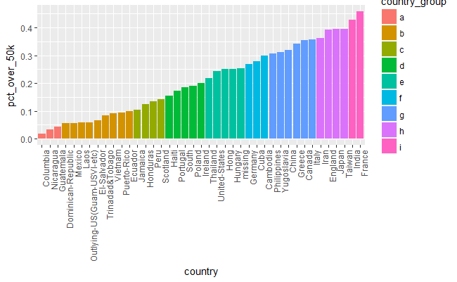

```r
train2 %>%
  mutate(country_group = cut(pct_over_50k, seq(0,.46, by = .051), labels = letters[1:9])) %>%
  select(country, country_group, pct_over_50k) %>%
  ggplot(aes(country, pct_over_50k)) + geom_bar(stat = 'identity', aes(fill = country_group)) +
  theme(axis.text.x = element_text(angle = 90, hjust = 1))
```

**marital status**  
It looks as if Married-AF and Married-civ could be combined into one group, and the remaining variables into another group

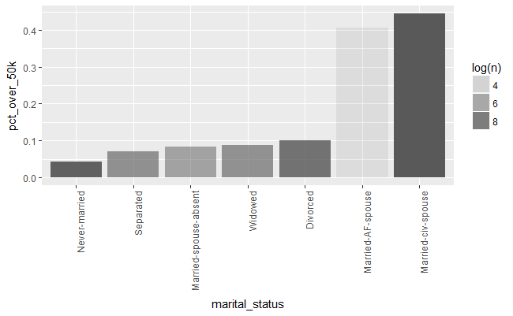

```r
train %>%
  group_by(marital_status) %>%
  summarise(pct_over_50k = sum(over_50k)/n(),
            n = n()) %>%
  arrange(pct_over_50k) %>%
  mutate(marital_status = factor(marital_status,levels = unique(marital_status))) %>%
  ggplot(aes(marital_status, pct_over_50k)) + geom_bar(aes(alpha = log(n)),stat = 'identity') +
  theme(axis.text.x = element_text(angle = 90, hjust = 1))
```

**occupation**  
This variable makes sense, with the executives and professional having the highest proportion of over 50k, and farming/fishing and hadlers-cleaners having a low proportion

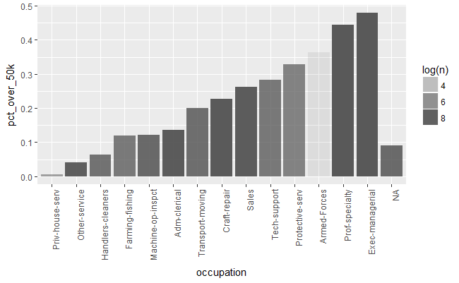

```r
train %>%
  group_by(occupation) %>%
  summarise(pct_over_50k = sum(over_50k)/n(),
            n = n()) %>%
  arrange(pct_over_50k) %>%
  mutate(occupation = factor(occupation,levels = unique(occupation))) %>%
  ggplot(aes(occupation, pct_over_50k)) + geom_bar(aes(alpha = log(n)),stat = 'identity') +
  theme(axis.text.x = element_text(angle = 90, hjust = 1))
```

**race**

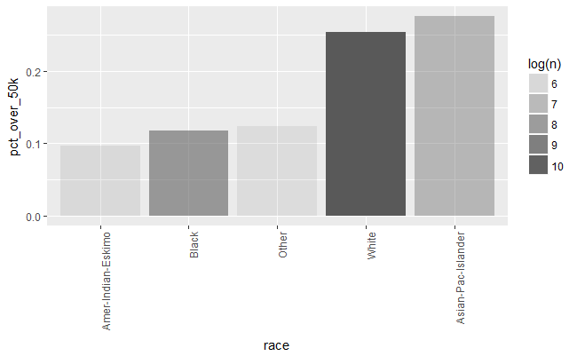

```r
train %>%
  group_by(race) %>%
  summarise(pct_over_50k = sum(over_50k)/n(),
            n = n()) %>%
  arrange(pct_over_50k) %>%
  mutate(race = factor(race, levels = unique(race))) %>%
  ggplot(aes(race, pct_over_50k)) + geom_bar(aes(alpha = log(n)),stat = 'identity') +
  theme(axis.text.x = element_text(angle = 90, hjust = 1))
```

**relationship**  
This variable follows closely with marital status. Only one may be useful to use.

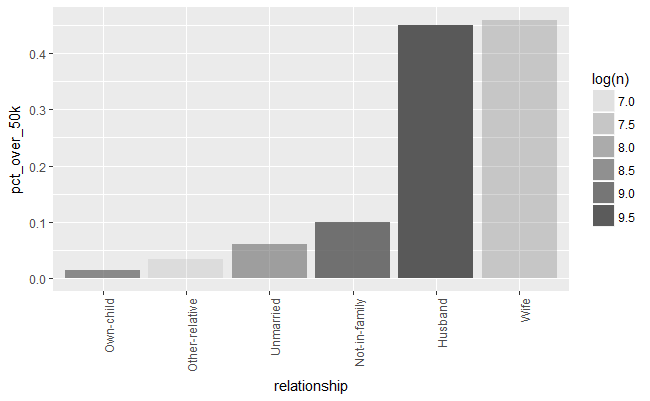

```r
train %>%
  group_by(relationship) %>%
  summarise(pct_over_50k = sum(over_50k)/n(),
            n = n()) %>%
  arrange(pct_over_50k) %>%
  mutate(relationship = factor(relationship, levels = unique(relationship))) %>%
  ggplot(aes(relationship, pct_over_50k)) + geom_bar(aes(alpha = log(n)),stat = 'identity') +
  theme(axis.text.x = element_text(angle = 90, hjust = 1))
```

**sex**  
It is surprising to see the likelihood of making over 50K being nearly 3 times higher for males than females

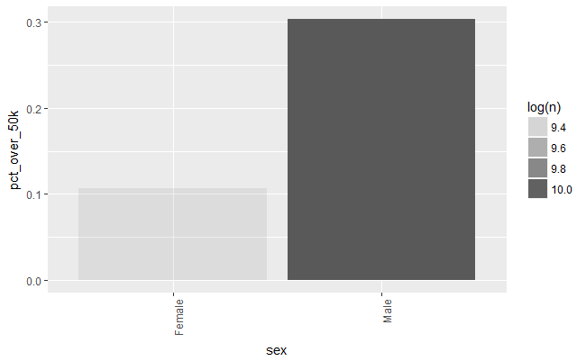

```r
train %>%
  group_by(sex) %>%
  summarise(pct_over_50k = sum(over_50k)/n(),
            n = n()) %>%
  arrange(pct_over_50k) %>%
  ggplot(aes(sex, pct_over_50k)) + geom_bar(aes(alpha = log(n)),stat = 'identity') +
  theme(axis.text.x = element_text(angle = 90, hjust = 1))
```

### Plotting Functions Used

( If this was production code or code I’d be handing off everything would be fully commented. )

```r
#'Create bins containing equal sample sizes spread across a variable
#'@description Create bins containing equal sample sizes. If the density is not
#'uniform then generic cuts in the data will not produce equal sample sizes among
#'the cuts.
#'@param variable  Variable of interest
#'@param n  The sample size for each bin
create_equal_bins <- function(variable, n){
  place <- 1:length(variable)
  n_bins <- ceiling(length(variable)/n)
  binned_var <- rep(1:n_bins,n) %>% sort %>% .[1:length(variable)]

  data.frame(place, variable) %>%
    arrange(variable) %>%
    mutate(binned_var = binned_var) %>%
    group_by(binned_var) %>%
    mutate(point = median(variable)) %>%
    ungroup() %>%
    arrange(place) -> out

  return(out)
}


#'Plot a continuous variable against a binary response
#'@description Plot a continuous variable against a binary response by
#'binning the variables and looking at the proportion of the response in each bin
#'@param variable  A binned version of the continuous variable
#'@param int An interaction term to add to the model. Can be used to fit more complicated relationships
#'@param n The number of datapoints for each condensed point
#'@param response Binary response variable
#'@param out Output the data used to create the plot or not. Accepts values of TRUE or FALSE
#'@param max_poly_degree The highest degree of polynomial to use for modeling
#'@param variable_name Name of the variable, Will be the title of the x-axis
#'@param jitter_height The random jitter of the actual points. the default may be too large or small
#'@param log_odds Should the y-axis be in terms of log odds or probability. T = log odds, F = Probability
#'@export
plot_continuous <- function(variable, int = NULL, n = 30, response, out = F,
                            max_poly_degree = 1, variable_name = 'variable',
                            jitter_height = 0.1, log_odds = T){

  df <- create_equal_bins(variable, n)
  df <- data.frame(df, response) %>% na.omit()

  df %>%
  group_by(point) %>%
  summarise(prob_warm = sum(response)/n(),
            n = n()) %>%
  mutate(odds = prob_warm/(1-prob_warm)) %>%
  mutate(log_odds = log(odds)) -> association_tbl

  if(is.null(int)){
    log_mod <- glm(response ~ poly(variable,max_poly_degree) ,data = df, family = "binomial") } else {
       log_mod <- glm(response ~ poly(variable,max_poly_degree) + int + I(int * variable) ,data = df, family = "binomial")
    }

  probs <- predict(log_mod , type = 'response')
  df$pred_prob <- probs
  df$pred_log_odds <- log(probs/(1-probs))

  max_log_odds <- max(association_tbl$log_odds[!is.infinite(association_tbl$log_odds)])
  min_log_odds <- min(association_tbl$log_odds[!is.infinite(association_tbl$log_odds)])
  add <- max(abs(association_tbl$log_odds[!is.infinite(association_tbl$log_odds)]))


  if(log_odds == T){
    df$plot_point <- ifelse(df$response == 1, max_log_odds + .1*add,
                            min_log_odds - .1*add)

    print(ggplot()+ geom_point(aes(x = association_tbl$point, y = association_tbl$log_odds)) +
            geom_line(aes(x = df$variable, y = df$pred_log_odds))+
            geom_jitter(aes(x = df$variable, y = df$plot_point),
                           color = 'blue', alpha = .05, height = jitter_height, width = 0) +
            xlab(variable_name) + ylab('log odds of making over 50k'))
  } else{
    df$plot_point <- ifelse(df$response == 1,max(df$pred_prob) + 0.15, min(df$pred_prob) - 0.15 )
    print(ggplot()+ geom_point(aes(x = association_tbl$point, y = association_tbl$prob_warm)) +
            geom_line(aes(x = df$variable, y = df$pred_prob))+
            geom_jitter(aes(x = df$variable, y = df$plot_point),
                        color = 'blue', alpha = .05, height = jitter_height, width = 0) +
            xlab(variable_name) + ylab('probability of making over 50k'))
  }

  if(out == T){
    return(list('points' = association_tbl, 'line' = df))
  }
}



#' Plot overlaying density plots of the variable against the response
#' @description Identify separation created by the independent variable on the response
#' @param variable independent variable
#' @param response response variable
#' @param variable_name name of independent variable or x-axis title
#' @export
plot_density <- function(variable, response, variable_name = 'variable'){
    data.frame(variable, response) %>%
    mutate(response = factor(response)) %>%
    rename(over_50k = response) -> density_plot

    print(ggplot(density_plot, aes(x = variable, fill = over_50k)) + geom_density(alpha = 0.2)+
      xlab(variable_name) + scale_fill_manual(values=c("blue", "red")))
}
```